# Netzwerkanalyse

# Kurze Einführung in Netzwerke

Nertzwerke stellen eine spezifische Art der Abstraktion von Beziehungen zwischen Objekten dar. Prinzipiell lässt sich (fast) alles als ein Netzwerk darstellen. In der Soziologie, aus der das Konzept der Netzwerke stammt, ist ein Netzwerk klassischerweise ein Geflecht aus Beziehungen. Beispielsweise von Freund*innen, Verwandten oder Bekannten. Jeder Person stellt dabei einen sogenannten **Knoten (Nodes)** dar. Die Beziehung unter ihnen wird durch **Kanten (Edges)** repräsentiert.

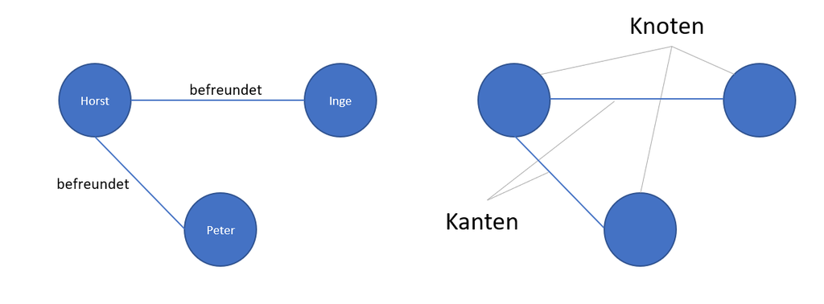

Wir können auch zahlreiche andere Beziehungen als Netzwerke darstellen. Neben Freundschaft oder Verwandtschaft von Personen könnte es auch das gemeinsame Vorkommen von Wörtern in einem Dokument sein. Dabei ist es wichtig, zwischen **gerichteten** und **ungerichteten** Netzwerken zu unterscheiden. **Ungerichtete Netzwerke** sind solche, bei denen es keinen Sinn macht, eine “Richtung” anzugeben. Zwei Personen sind immer gleichermaßen miteinander befreundet oder verwandt. Ein einseitiges Verhältnis, bei dem Inge zwar mit Horst, Horst aber nicht mit Peter, oder Oma zwar mit Mutti, Mutti aber nicht mit Oma verwandt ist, gibt es nicht. **Bei ungerichteten Netzwerken haben die Kanten keine Richtung.** Anders ist es bei **gerichteten Netzwerken**. Dort ist es wichtig, wer mit wem interagiert. Horst schreibt Inge einen Brief, diese schreibt ihm aber keinen. Ein User in einem sozialen Netzwerk erwähnt einen anderen, dieser erwähnt ihn aber nicht. **Bei gerichteten Netzwerken ist die Richtung der Kanten entscheidend.**

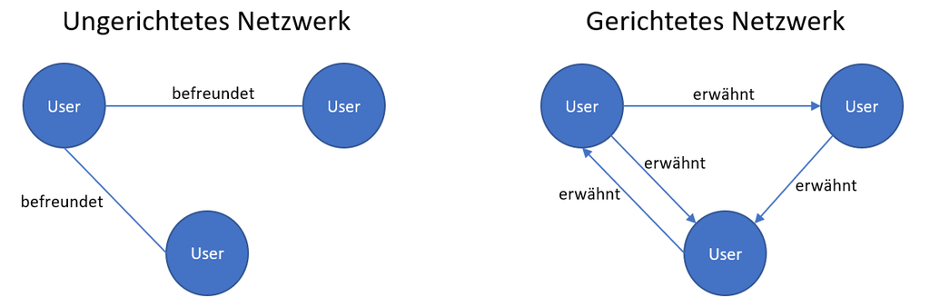

Außerdem wird in der Regel zwischen **monopartiten** **Netzwerken** und **bipartiten Netzwerken** (manchmal auch *1-mode* und *2-mode* Netzwerke genannt) unterschieden. **Monopartite Netzwerke bestehen aus einem einzigen Knotentyp**. Also Usern, die einander erwähnen, Personen, die befreundet sind, Wörter, die gemeinsam vorkommen, usw. **Ein bipartites Netzwerk besteht aus zwei unterschiedlichen Knotentypen, wobei nur Knoten unterschiedlchen Typs in Beziehung stehen können.** Ein Beispiel wäre ein Netzwerk aus YouTube Videos und Userkommentaren. Während User Videos kommentieren können, können sie nicht direkt andere User kommentieren. Sie könnten zwar deren Kommentare kommentieren - aber das wäre wiederum eine andere Art von Netzwerk. Genausowenig können die Videos einander kommentieren. Sie könnten aufeinander über die vorgeschlagenen Videos verweisen, aber auch das wäre wieder ein anderes, monopartites Netzwerk. Es ist also wichtig, sich zu überlegen, auf welche Art und Weise man die Realität abstrahieren will und welcher Netzwerktyp dafür am geeignetsten ist.

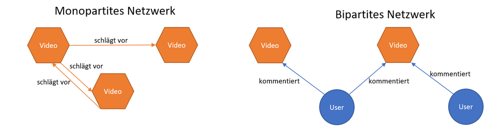